# 03_DataMerging

Niklas Jocher

2025-11-19

# Set global chunk options

```r
knitr::opts_chunk$set(echo = TRUE, warning = FALSE, message = FALSE)
library(tidyverse)
```

# 0. Load the CSVs

First, we need to load the CSV files that we want to merge together. In this case, using the prediction tendencies and TRFs seems like a good idea.

```r
data_path_trf <- "/Users/niklasjocher/Desktop/ES data/ga_df_dist2.csv"
df_dist2 <- read_csv(data_path_trf)

data_path_pd <- "/Users/niklasjocher/Desktop/ES data/prediction-values.csv"
df_predict <- read_csv(data_path_pd)
```

# 1. Merge the CSVs

Now that we have the CSVs in our env, we want to merge them. To do this we need to choose a parameter we want to merge the two files on. In our case we use the subject_id.

```r
df_merged <- inner_join(df_dist2, df_predict, by = "subject_id")
```

# 2. Summarize the new Dataframe

```r
df_merged_t1 <- df_merged %>%
  filter(time >= 0.08, time <= 0.2) %>%    # filter time window
  group_by(subject_id, condition) %>%       # group by subject and condition
  summarise(across(where(is.numeric), mean, na.rm = TRUE)) %>%
  ungroup()

head(df_merged_t1)
```

```
## # A tibble: 6 × 8
##   subject_id condition   ...1.x  time Amplitude ...1.y pred_tend pred_err
##        <dbl> <chr>        <dbl> <dbl>     <dbl>  <dbl>     <dbl>    <dbl>
## 1          0 distractor1     39  0.14 0.0000440      0     0.307  -0.124
## 2          0 distractor2    165  0.14 0.0000624      0     0.307  -0.124
## 3          0 target         291  0.14 0.0000499      0     0.307  -0.124
## 4          1 distractor1    417  0.14 0.0000360      1     0.374   0.0229
## 5          1 distractor2    543  0.14 0.0000286      1     0.374   0.0229
## 6          1 target         669  0.14 0.0000311      1     0.374   0.0229
```

# 3. Plotting

We are going to use a scatter plot for this. We put the Prediction tendencie on the x axis the amplitude on the y axis and use the color parameter to display the three conditions. WIth geom_smooth we can also add a regression line for each conditions.

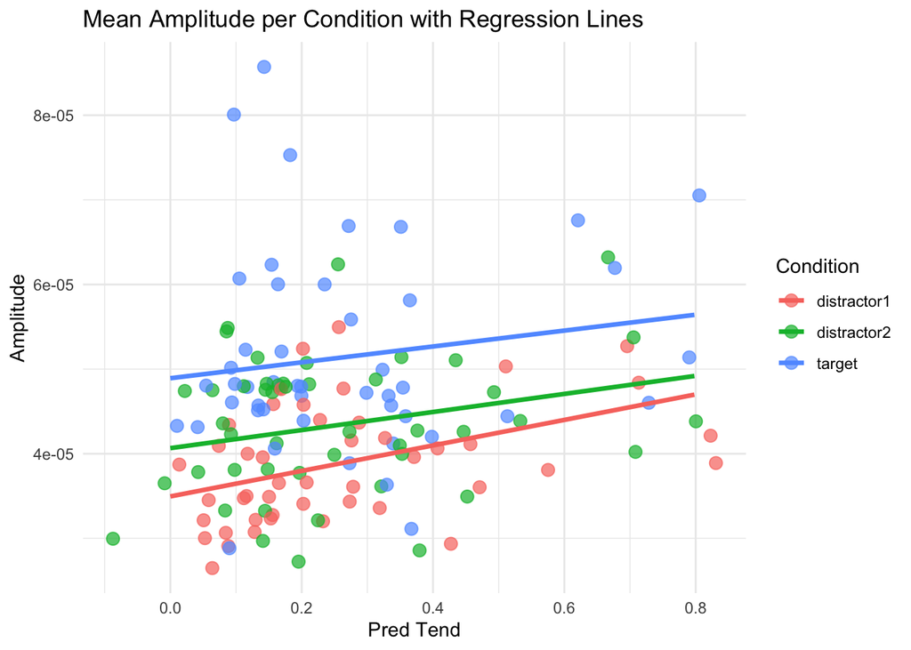

```r
ggplot(df_merged_t1, aes(x = pred_tend, y = Amplitude, color = factor(condition))) +
  geom_jitter(width = 0.1, height = 0, size = 3, alpha = 0.7) +
  geom_smooth(method = "lm", se = FALSE, linewidth = 1.2) +
  theme_minimal() +
  labs(
    title = "Mean Amplitude per Condition with Regression Lines",
    x = "Pred Tend",
    y = "Amplitude",
    color = "Condition"
  )
```

# 4. Correlation table

Maybe it would also be interesting to see if Amplitude and pred_tend correlate. We can do this and ignore the conditions:

```r
cor_table <- df_merged_t1 %>%
  select(Amplitude, pred_tend) %>%
  cor()


cor_table
```

```
##           Amplitude pred_tend
## Amplitude 1.0000000 0.1984353
## pred_tend 0.1984353 1.0000000
```

Or we do condition specific correlations

```r
df_merged_t1 %>%
  group_by(condition) %>%
  summarise(correlation = cor(Amplitude, pred_tend))
```

```
## # A tibble: 3 × 2
##   condition   correlation
##   <chr>             <dbl>
## 1 distractor1       0.389
## 2 distractor2       0.233
## 3 target            0.142
```

# 5. Visualize Correlations

Scatterplots With Regression Lines faceted by condition

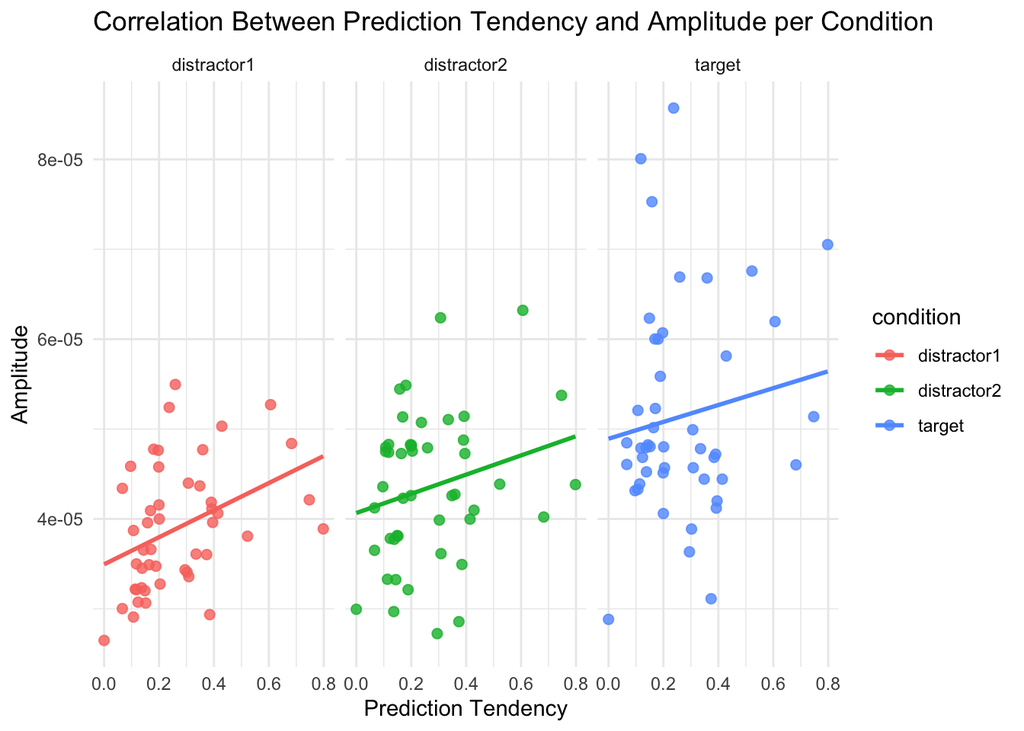

```r
ggplot(df_merged_t1, aes(x = pred_tend, y = Amplitude, color = condition)) +
  geom_point(alpha = 0.8, size = 2) +
  geom_smooth(method = "lm", se = FALSE, linewidth = 1) +
  facet_wrap(~ condition) +
  theme_minimal() +
  labs(
    title = "Correlation Between Prediction Tendency and Amplitude per Condition",
    x = "Prediction Tendency",
    y = "Amplitude"
  )
```